# Study 1 analysis: initial learning tasks

George Kinnear

11/08/2021

```r
library(tidyverse)

#Plots
library(ggplot2)
library(patchwork) # for combining plots
library(ggtext) # for markdown in plots
library(latex2exp) # for formatting latex in plot captions

# For Bayesian stats:
library(bayestestR)
#library(insight)
#library(see)
library(rstanarm)
library(tidybayes)
#library(BayesFactor)
ci_width = 0.95  # Use 95% HDIs
set.seed(20210518)

# Tables
library(knitr)
library(kableExtra)
basic_kable = function(df, ...) {
  df %>%
    kable(...) %>%
    kable_styling(bootstrap_options = "striped", full_width = F)
}

# Plot styling
heathers = c("#00b3c3","#e51c24","#016637","#fcb123")
heathers = c("#87005a", "#c66005","#016637","#fcb123")
groupcolours = c("C-CG" = heathers[1],
                 "C-GC" = "#6f004a", # darker heathers1
                 "G-CG" = heathers[2],
                 "G-GC" = "#a34e03" # darker heathers2
                 )
four_groups = c("CCG", "CGC", "GCG", "GGC")
theme_set(theme_minimal())
```

```r
question_marks = read_csv("data-clean/study1/FAC_LGE-tasks.csv") %>%
  select(question_name, marks_available)

attempt_data_all = read_rds("data-clean/FAC_LGE-attempt_data.rds") %>%
  # tidy up group names
  mutate(
    group = str_replace(group, "LGE Group ", ""),
    group = str_glue("{str_sub(group, 1, 1)}-{str_sub(group, 2, 3)}"),
    overall_group = str_sub(group, 1, 1)
  ) %>%
  mutate(
    quiz = case_when(
      question_name %in% c("FarC1", "FarC2") ~ "FT",
      str_detect(question_name, "Mid") ~ "S2",
      TRUE ~ "S1"
    )
  ) %>%
  left_join(question_marks, by = "question_name") %>%
  mutate(
    # default to 1 mark per question if not specified
    marks_available = replace_na(marks_available, 1),
    marks_attained = fraction * marks_available
  )
```

# Item performance

```r
first_attempts = attempt_data_all %>%
  filter(attempt_number == 1) %>%
  group_by(quiz, question_name, username) %>%
  select(quiz, question_name, username, fraction, attempt_number) %>%
  ungroup()

last_attempts = attempt_data_all %>%
  group_by(quiz, question_name, username) %>%
  # select the final attempt
  top_n(n = 1, wt = attempt_number) %>%
  select(quiz, question_name, username, fraction, attempt_number) %>%
  ungroup()

best_attempts = attempt_data_all %>%
  group_by(quiz, question_name, username) %>%
  # select the best attempt
  top_n(n = 1, wt = fraction) %>%
  slice(1) %>%
  select(quiz, question_name, username, fraction, attempt_number) %>%
  ungroup()

attempts_summary = bind_rows(
  list("first" = first_attempts,
       "last" = last_attempts,
       "best" = best_attempts),
  .id = "attempt_type"
)

attempts_summary_stats = attempts_summary %>%
  filter(attempt_type != "best") %>%
  group_by(quiz, question_name, attempt_type) %>%
  summarise(
    mean_score = mean(fraction, na.rm = TRUE),
    null_response = sum(is.na(fraction)) / n(),
    n = n(),
    .groups = "drop"
  ) %>%
  ungroup() %>%
  mutate(
    plot_order = case_when(
      str_detect(question_name, "^C") ~ "1. Learning (C)",
      str_detect(question_name, "^G") ~ "1. Learning (G)",
      str_detect(question_name, "Near") ~ "2. Near",
      str_detect(question_name, "Mid") ~ "3. Mid",
      str_detect(question_name, "Far") ~ "4. Far"
    )
  )
```

This shows the mean score on each of the items:

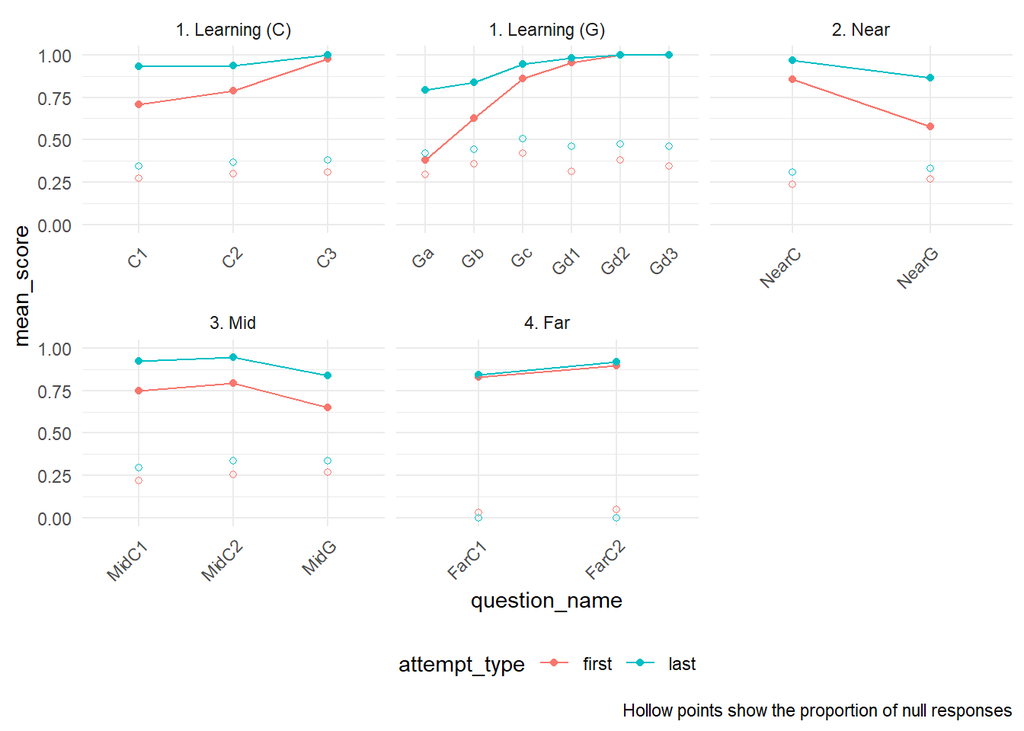

```r
attempts_summary_stats %>%
  ggplot(aes(x = question_name,
             y = mean_score,
             colour = attempt_type,
             group = attempt_type)) +
  geom_point() +
  geom_line() +
  geom_point(data = attempts_summary_stats,
             mapping = aes(x = question_name,
                 y = null_response),
             shape = 1) +
  facet_wrap(~plot_order, scales = "free_x") +
  theme_minimal() +
  theme(axis.text.x = element_text(angle = 45, hjust = 1),
        legend.position = "bottom") +
  ylim(c(0,1)) +
  labs(caption = "Hollow points show the proportion of null responses")
```

## Initial learning task: Classification

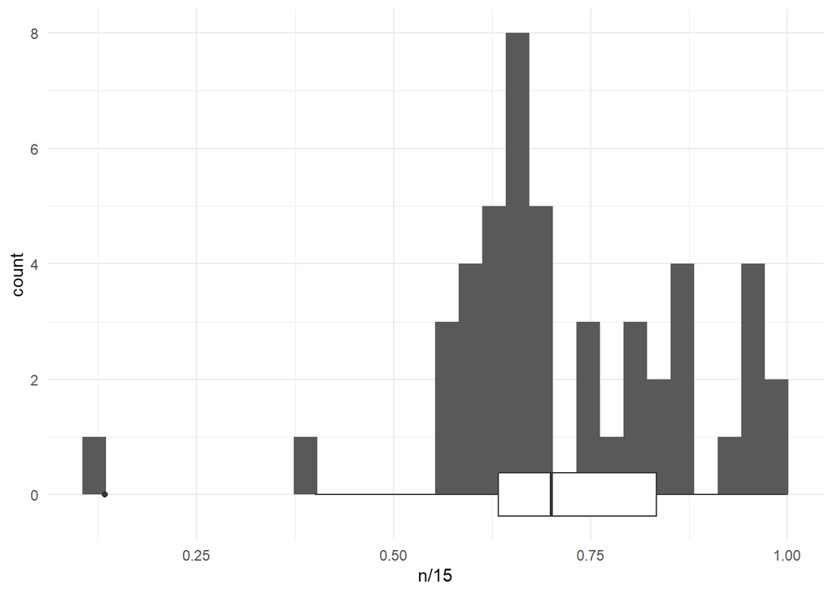

```r
per_student_C_marks <- attempt_data_all %>%
  filter(str_detect(question_name, "^C"),
         str_detect(group, "C-"),
         attempt_number == 1,
         !is.na(marks_attained)) %>%
  select(question_name, username, marks_attained) %>%
  group_by(username) %>%
  tally(marks_attained)

per_student_C_marks %>%
  ggplot(aes(x = n/15)) +
  geom_histogram() +
  geom_boxplot()
```

```r
per_student_C_marks %>%
  summarise(mean = mean(n), mean_pc = mean/15*100, .groups = "drop") %>%
  basic_kable()
```

| mean | mean_pc |
| --- | --- |
| 10.82979 | 72.19858 |

```r
# Separate the raw response data into details of the 10 different sub-parts
# - extract the details of which sub-part is which of the Alcock & Simpson items (item_part)
# - plus the corresponding response (ans_part) and score (score_part) for each sub-part
responses_C1 <- attempt_data_all %>%
  filter(question_name == "C1",
         attempt_number == 1,
         !is.na(marks_attained)) %>%
  select(group, username, questionsummary, responsesummary, marks_attained) %>%
  # pick out the responses to each part
  # STACK output uses [score] to separate the responses to each part; use NA to discard the final bit that is about the PRTs
  separate(col = responsesummary,
           into = c(paste0("ans_part", c(1:10)), NA),
           sep = "\\[score\\]; ",
           remove = FALSE) %>%
  mutate(across(contains("ans"), ~ str_remove(., ".*: "))) %>%
  # pick out the scores for each part (this time discarding the first bit that holds the responses)
  separate(col = responsesummary,
           into = paste0("score_part", c(0:10)),
           sep = "\\| prt") %>%
  select(-score_part0) %>%
  mutate(across(contains("score"), ~ str_remove(., ";.*"))) %>%
  mutate(across(contains("score"), ~ str_remove(., ".*-.*-"))) %>%
  mutate(questionsummary = str_remove_all(questionsummary, "\\[|\\]")) %>%
  separate(col = questionsummary,
           into = paste0("item_part", c(1:10)),
           sep = ",")

responses_C2 <- attempt_data_all %>%
  filter(question_name == "C2",
         attempt_number == 1,
         !is.na(marks_attained)) %>%
  select(group, username, questionsummary, responsesummary, marks_attained) %>%
  # pick out the responses to each part
  separate(col = responsesummary,
           # interleave vectors https://stackoverflow.com/a/50516988
           into = c(as.vector(rbind(paste0("ans_part", c(11:13)),c(NA,NA,NA))), NA),
           sep = "\\[score\\]; ",
           remove = FALSE) %>%
  mutate(across(contains("ans"), ~ str_remove(., ".*: "))) %>%
  # pick out the scores for each part (this time discarding the first bit that holds the responses)
  separate(col = responsesummary,
           into = c(NA, as.vector(rbind(paste0("score_part", c(11:13)),c(NA,NA,NA)))),
           sep = "\\| prt") %>%
  mutate(across(contains("score"), ~ str_remove(., ";.*"))) %>%
  mutate(across(contains("score"), ~ str_remove(., ".*-.*-"))) %>%
  mutate(questionsummary = str_remove_all(questionsummary, "\\[|\\]")) %>%
  separate(col = questionsummary,
           into = paste0("item_part", c(11:13)),
           sep = ",") %>%
  # make the item numbers 11,12,13 instead of 1,2,3
  rowwise() %>%
  mutate(across(contains("item_part"), ~ as.character(sum(c(as.numeric(.x), 10)))))

responses_C3 <- attempt_data_all %>%
  filter(question_name == "C3",
         attempt_number == 1,
         !is.na(marks_attained)) %>%
  select(group, username, questionsummary, responsesummary, marks_attained) %>%
  # pick out the responses to each part
  separate(col = responsesummary,
           into = c(paste0("ans_part", c(14:15)), NA),
           sep = "\\[score\\]; ",
           remove = FALSE) %>%
  mutate(across(contains("ans"), ~ str_remove(., ".*: "))) %>%
  # pick out the scores for each part (this time discarding the first bit that holds the responses)
  separate(col = responsesummary,
           into = c(NA,paste0("score_part", c(14:15))),
           sep = "\\| prt") %>%
  mutate(across(contains("score"), ~ str_remove(., ";.*"))) %>%
  mutate(across(contains("score"), ~ str_remove(., ".*-.*-"))) %>%
  mutate(questionsummary = str_remove_all(questionsummary, "\\[|\\]")) %>%
  separate(col = questionsummary,
           into = paste0("item_part", c(14:15)),
           sep = ",") %>%
  # make the item numbers 14,15 instead of 1,2
  rowwise() %>%
  mutate(across(contains("item_part"), ~ as.character(sum(c(as.numeric(.x), 13)))))

responses_C_long = responses_C1 %>%
  select(-marks_attained) %>%
  full_join(responses_C2 %>% select(-marks_attained), by = c("group", "username")) %>%
  full_join(responses_C3 %>% select(-marks_attained), by = c("group", "username")) %>%
  pivot_longer(
    # take variables of the form STUFF_partN and separate
    # into a column for each kind of STUFF and store the
    # values of N in a column called "part"
    contains("part"),
    names_to = c(".value", "part"),
    names_sep = "_part"
  ) %>%
  mutate(score = if_else(score == "T", 1, 0)) %>%
  mutate(score = replace_na(score, 0),
         item = as.integer(item),
         item = as.factor(item),
         ans = str_remove_all(ans, '\\"| '),
         ans = na_if(ans, ""))
```

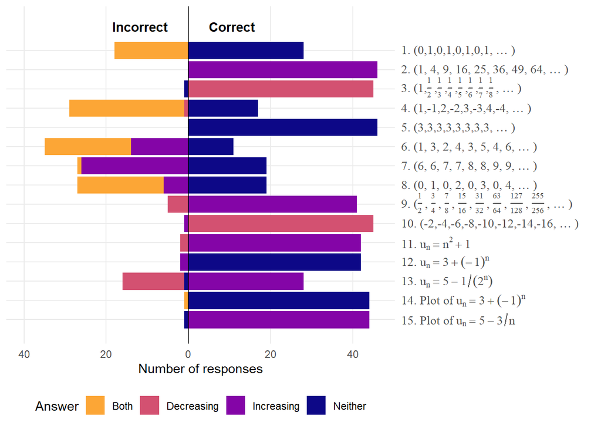

```r
responses_C_summary = responses_C_long %>%
  # we are only interested in responses from the students completing the question during the learning task,
  # not students from the G- group completing the question later when the materials were made available
  filter(str_detect(group, "C-")) %>%
  group_by(item, ans) %>%
  summarise(
    count = n(),
    .groups = "drop"
  ) %>%
  arrange(item) %>%
  group_by(item) %>%
  mutate(
    correct_ans = case_when(
      item %in% c(2,9,11,13,15) & ans == "Increasing" ~ "Correct",
      item %in% c(3,10) & ans == "Decreasing" ~ "Correct",
      item %in% c(1,4,5,6,7,8,12,14) & ans == "Neither" ~ "Correct",
      TRUE ~ "Incorrect"
    ),
    signed_count = if_else(correct_ans == "Correct", count, -count),
    signed_prop = signed_count / sum(count*!is.na(ans))
  ) %>%
  drop_na()

# library(latex2exp) needed here
windowsFonts(Times=windowsFont("TT Times New Roman"))
responses_C_summary %>%
  mutate(item = as.numeric(item)) %>%
  ggplot(aes(x = item, y = signed_count, fill = ans)) +
  geom_bar(position = "stack", stat = "identity") +
  geom_hline(yintercept = 0) +
  #scale_fill_viridis_d("Answer", end = 0.85, option = "viridis") +
  scale_fill_viridis_d("Answer", option = "plasma", end = 0.8, direction = -1) +
  #scale_fill_grey("Answer", end = 0.8) +
  scale_y_continuous("Number of responses", labels = abs, breaks = seq(-40, 40, 20)) +
  scale_x_reverse(
    position = "top",
    breaks = c(1:15),
    minor_breaks = c(1:15),
    labels = c(
      "1" = parse(text = TeX("1. (0,1,0,1,0,1,0,1,\\ldots)")),
      "2" = parse(text = TeX("2. (1, 4, 9, 16, 25, 36, 49, 64,\\ldots)")),
      #"3" = parse(text = TeX("3. (1,\\frac{1}{2},\\frac{1}{3},\\frac{1}{4},\\frac{1}{5},\\frac{1}{6},\\frac{1}{7},\\frac{1}{8},\\ldots)")),
      "3" = parse(text = TeX("3. (1,\\frac{$_1$}{$^2$},\\frac{$_1$}{$^3$},\\frac{$_1$}{$^4$},\\frac{$_1$}{$^5$},\\frac{$_1$}{$^6$},\\frac{$_1$}{$^7$},\\frac{$_1$}{$^8$},\\ldots)")),
      "4" = parse(text = TeX("4. (1,-1,2,-2,3,-3,4,-4,\\ldots)")),
      "5" = parse(text = TeX("5. (3,3,3,3,3,3,3,3,\\ldots)")),
      "6" = parse(text = TeX("6. (1, 3, 2, 4, 3, 5, 4, 6,\\ldots)")),
      "7" = parse(text = TeX("7. (6, 6, 7, 7, 8, 8, 9, 9,\\ldots)")),
      "8" = parse(text = TeX("8. (0, 1, 0, 2, 0, 3, 0, 4,\\ldots)")),
      #"9" = parse(text = TeX("9. (\\frac{1}{2}, \\frac{3}{4}, \\frac{7}{8}, \\frac{15}{16}, \\frac{31}{32}, \\frac{63}{64}, \\frac{127}{128}, \\frac{255}{256},\\ldots)")),
      "9" = parse(text = TeX("9. (\\frac{$_1$}{$^2$}, \\frac{$_3$}{$^4$}, \\frac{$_7$}{$^8$}, \\frac{$_{15}$}{$^{16}$}, \\frac{$_{31}$}{$^{32}$}, \\frac{$_{63}$}{$^{64}$}, \\frac{$_{127}$}{$^{128}$}, \\frac{$_{255}$}{$^{256}$},\\ldots)")),
      "10" = parse(text = TeX("10. (-2,-4,-6,-8,-10,-12,-14,-16,\\ldots)")),
      "11" = parse(text = TeX("11. $u_n = n^2+1$")),
      "12" = parse(text = TeX("12. $u_n = 3+(-1)^n$")),
      "13" = parse(text = TeX("13. $u_n = 5-1/(2^n)$")),
      "14" = parse(text = TeX("14. Plot of $u_n = 3+(-1)^n$")),
      "15" = parse(text = TeX("15. Plot of $u_n = 5-3/n$"))
    )
  ) +
  labs(x = "") +
  coord_flip() +
  expand_limits(y = c(-40,40)) +
  annotate("text", x = -0.5, y = 5, label = "Correct", fontface = "bold", hjust = "left", vjust = "top") +
  annotate("text", x = -0.5, y = -5, label = "Incorrect", fontface = "bold", hjust = "right", vjust = "top") +
  theme(axis.text.y = element_text(family="Times", size = 10),
        panel.grid.minor.x = element_blank(),
        legend.position = "bottom")
```

```r
ggsave("figs/FIG_study1_responses_C.eps", width = 18, height = 12, units = "cm", device = cairo_ps)


options(knitr.kable.NA = '')
responses_C_summary %>%
  pivot_wider(
    id_cols = item,
    names_from = ans,
    values_from = count
  ) %>%
  basic_kable(
    #format = "latex", booktabs = T
  )
```

| item | Both | Neither | Increasing | Decreasing |
| --- | --- | --- | --- | --- |
| 1 | 18 | 28 |  |  |
| 2 |  |  | 46 |  |
| 3 |  | 1 |  | 45 |
| 4 | 28 | 17 |  | 1 |
| 5 |  | 46 |  |  |
| 6 | 21 | 11 | 14 |  |
| 7 | 1 | 19 | 26 |  |
| 8 | 21 | 19 | 6 |  |
| 9 |  |  | 41 | 5 |
| 10 |  |  | 1 | 45 |
| 11 |  |  | 42 | 2 |
| 12 |  | 42 | 2 |  |
| 13 |  | 1 | 28 | 15 |
| 14 | 1 | 44 |  |  |
| 15 |  | 1 | 44 |  |

## Initial learning task: Example generation

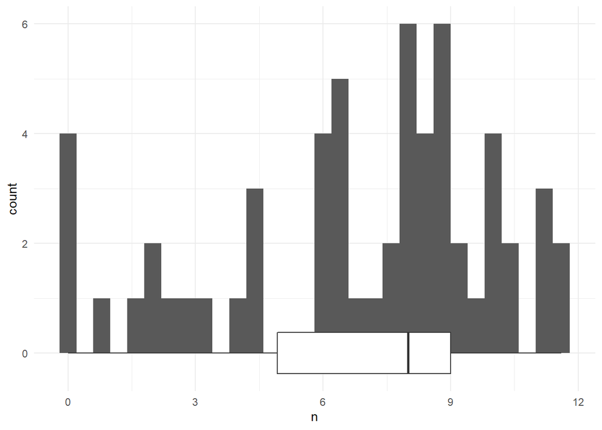

```r
per_student_G_marks <- attempt_data_all %>%
  filter(str_detect(question_name, "^G"),
         str_detect(group, "G-"),
         attempt_number == 1,
         !is.na(marks_attained)) %>%
  select(question_name, username, marks_attained) %>%
  group_by(username) %>%
  tally(marks_attained)

per_student_G_marks %>%
  ggplot(aes(x = n)) +
  geom_histogram() +
  geom_boxplot()
```

```r
per_student_G_marks %>%
  summarise(mean = mean(n), mean_pc = mean/12*100, .groups = "drop") %>%
  basic_kable()
```

| mean | mean_pc |
| --- | --- |
| 6.889655 | 57.41379 |

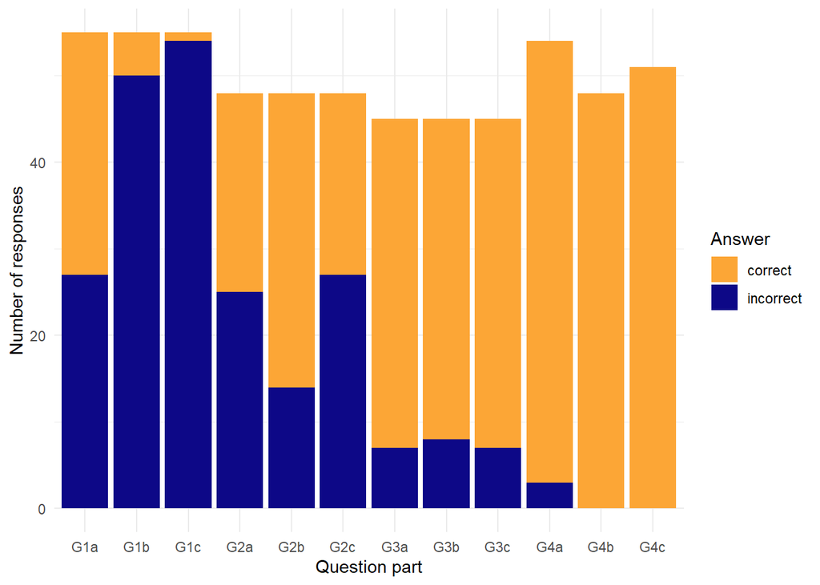

```r
responses_G <- attempt_data_all %>%
  filter(
    str_detect(question_name, "^G"),
    # focus on students doing this as their initial learning task
    str_detect(group, "G-"),
    attempt_number == 1,
    !is.na(marks_attained)
  ) %>%
  select(group, username, question_name, questionsummary, responsesummary, marks_attained) %>%
  # pick out the various answers - str_match_all returns a matrix, which we have to wrangle a bit
  mutate(ans_bits = str_match_all(responsesummary, "(ans[^:]*): ([^;]*)(?=\\[score\\];)")) %>%
  #mutate(ans_bits = str_match_all(responsesummary, "(ans[:digit:]): ([^;]*)(?=\\[score\\];)")) %>%
  mutate(ans_bits = map(ans_bits, ~ tibble(part = .x[,2], response = .x[,3]))) %>%
  unnest(ans_bits) %>%
  # this pulls out all the PRT parts, but we don't actually need to - see "fully_correct" below
  #mutate(prt_bits = str_match_all(responsesummary, "(prt[:digit:]): ([^;]*)(?=; |$)")) %>%
  #mutate(prt_bits = map(prt_bits, ~ tibble(prt = .x[,2], tree = .x[,3]))) %>%
  #unnest(prt_bits) %>%
  # construct a simplified name for each question part
  mutate(
    G_part = case_when(
      # Gc has an unmarked part asking for some explanation
      part == "ans1_whydifferent" ~ NA_character_,
      # Convert Ga ans1 to G1a, Gb ans3 to G2c etc
      question_name == "Ga" ~ paste0("G1", letters[parse_number(part)]),
      question_name == "Gb" ~ paste0("G2", letters[parse_number(part)]),
      question_name == "Gc" ~ paste0("G3", letters[parse_number(part)]),
      # Convert Gd1/Gd2/Gd3 to G4a/b/c
      str_detect(question_name, "Gd") ~ paste0("G4", letters[parse_number(question_name)])
    ),
    fully_correct = case_when(
      G_part == "G1a" ~ str_detect(responsesummary, "prt1-1-T"),
      G_part == "G1b" ~ str_detect(responsesummary, "prt2-4-T"),
      G_part == "G1c" ~ str_detect(responsesummary, "prt3-4-T") & str_detect(responsesummary, "prt3-5-T"), # check that u4 has the right value too
      G_part == "G2a" ~ str_detect(responsesummary, "prt1-1-T"),
      G_part == "G2b" ~ str_detect(responsesummary, "prt2-4-T"),
      G_part == "G2c" ~ str_detect(responsesummary, "prt3-4-T") & str_detect(responsesummary, "prt3-5-T"),
      G_part == "G3a" ~ str_detect(responsesummary, "prt1-1-T"),
      G_part == "G3b" ~ str_detect(responsesummary, "prt2-1-T"),
      G_part == "G3c" ~ str_detect(responsesummary, "prt3-7-T"),
      G_part == "G4a" ~ str_detect(responsesummary, "prt1-1-T"),
      G_part == "G4b" ~ str_detect(responsesummary, "prt1-1-T"),
      G_part == "G4c" ~ str_detect(responsesummary, "prt1-2-T"),
    ),
    relevant_prt = case_when(
      # pick out the PRT trace that is relevant to each part, i.e. that grades that answer
      is.na(G_part) ~ NA_character_,
      question_name %in% c("Ga", "Gb", "Gc") ~ str_match_all(responsesummary, str_glue("prt{parse_number(part)}: [^;]*(?=; |$)")) %>% as.character(),
      TRUE ~ str_match_all(responsesummary, str_glue("prt1: [^;]*(?=; |$)")) %>% as.character()
    )
  ) %>%
  select(-contains("summary"))

responses_G_summary <- responses_G %>%
  janitor::tabyl(G_part, fully_correct) %>%
  select(part = G_part, incorrect = "FALSE", correct = "TRUE")

responses_G_summary %>%
  filter(!is.na(part)) %>%
  pivot_longer(cols = contains("correct"), names_to = "type", values_to = "count") %>%
  ggplot(aes(x = part, y = count, fill = type)) +
  geom_bar(position = "stack", stat = "identity") +
  scale_fill_viridis_d("Answer", option = "plasma", end = 0.8, direction = -1) +
  scale_y_continuous("Number of responses") +
  labs(x = "Question part")
```

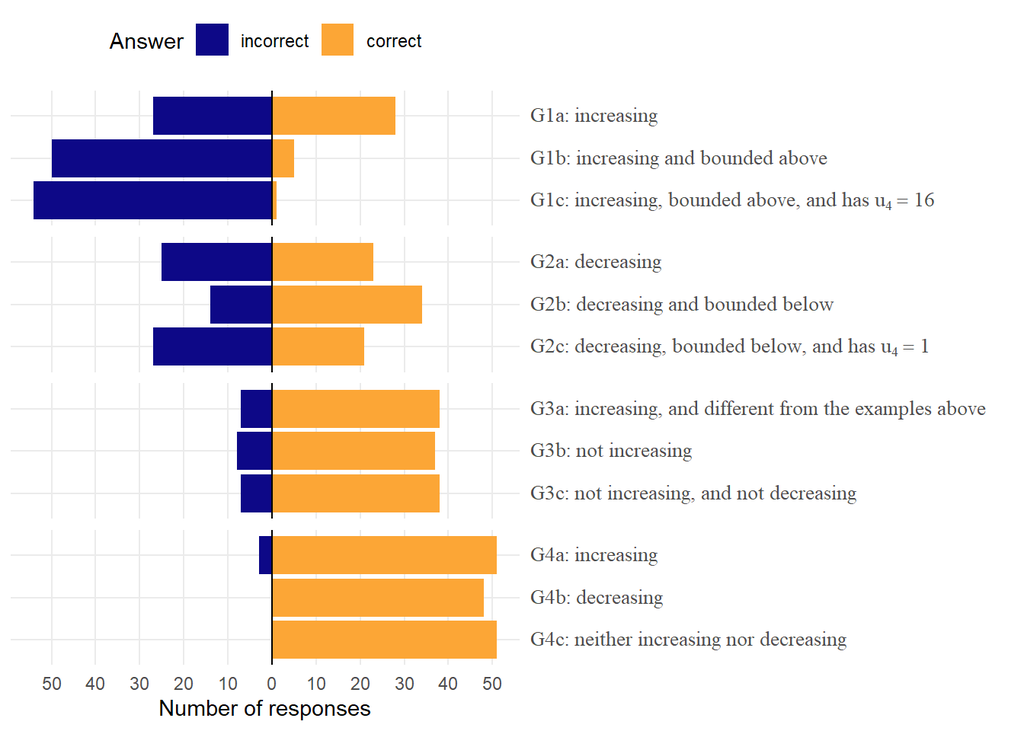

```r
responses_G_summary %>%
  filter(!is.na(part)) %>%
  mutate(part = fct_rev(part)) %>%
  pivot_longer(cols = contains("correct"), names_to = "type", values_to = "count") %>%
  mutate(signed_count = if_else(type == "correct", count, -count)) %>%
  ggplot(aes(x = part, y = signed_count, fill = type)) +
  geom_bar(position = "stack", stat = "identity") +
  geom_hline(yintercept = 0) +
  #scale_fill_viridis_d("Answer", end = 0.85, option = "viridis") +
  scale_fill_viridis_d("Answer", option = "plasma", end = 0.8, direction = -1, guide = guide_legend(reverse = TRUE)) +
  #scale_fill_grey("Answer", end = 0.8) +
  scale_y_continuous("Number of responses", labels = abs, breaks = seq(-50, 50, 10)) +
  scale_x_discrete(
    position = "top",
    labels = c(
      "G1a" = "G1a: increasing",
      "G1b" = "G1b: increasing and bounded above",
      "G1c" = parse(text = TeX("G1c: increasing, bounded above, and has $u_4=16$")),
      "G2a" = "G2a: decreasing",
      "G2b" = "G2b: decreasing and bounded below",
      "G2c" = parse(text = TeX("G2c: decreasing, bounded below, and has $u_4=1$")),
      "G3a" = "G3a: increasing, and different from the examples above",
      "G3b" = "G3b: not increasing",
      "G3c" = "G3c: not increasing, and not decreasing",
      "G4a" = "G4a: increasing",
      "G4b" = "G4b: decreasing",
      "G4c" = "G4c: neither increasing nor decreasing"
    )
  ) +
  labs(x = "") +
  coord_flip() +
  expand_limits(y = c(-50,50)) +
  #annotate("text", x = 13.2, y = 5, label = "Correct", fontface = "bold", hjust = "left", vjust = "top") +
  #annotate("text", x = 13.2, y = -5, label = "Incorrect", fontface = "bold", hjust = "right", vjust = "top") +
  theme(axis.text.y = element_text(family="Times", size = 10),
        panel.grid.minor.x = element_blank(),
        strip.text.y = element_blank(),
        legend.position = "top") +
  facet_grid(rows = vars(str_sub(part, start = 1, end = 2)), scales = "free", space = "free")
```

```r
ggsave("figs/FIG_study1_responses_G.eps", width = 18, height = 9, units = "cm", device = cairo_ps)

responses_G_summary %>%
  filter(!is.na(part)) %>%
  basic_kable()
```

| part | incorrect | correct |
| --- | --- | --- |
| G1a | 27 | 28 |
| G1b | 50 | 5 |
| G1c | 54 | 1 |
| G2a | 25 | 23 |
| G2b | 14 | 34 |
| G2c | 27 | 21 |
| G3a | 7 | 38 |
| G3b | 8 | 37 |
| G3c | 7 | 38 |
| G4a | 3 | 51 |
| G4b | 0 | 48 |
| G4c | 0 | 51 |

Summary of responses to G1-G3:

```r
responses_G %>%
  filter(!str_detect(G_part, "G4")) %>%
  group_by(G_part, fully_correct, relevant_prt, response) %>%
  tally() %>%
  group_by(G_part, fully_correct, relevant_prt) %>%
  summarise(
    num_responses = sum(n),
    responses = paste0(str_trim(response), collapse = "; "),
    .groups = "drop"
  ) %>%
  basic_kable() %>%
  collapse_rows(columns = 1:2, valign = "top")
```

| G_part | fully_correct | relevant_prt | num_responses | responses |
| --- | --- | --- | --- | --- |
| G1a | FALSE | prt1: ATAlgEquiv_SA_not_logic. \| prt1-1-F \| ATAlgEquiv_SA_not_logic. \| prt1-2-F | 2 | (-1)^n; u^n |
| G1a | FALSE | prt1: prt1-1-F \| ATLogic_True \| prt1-2-T | 25 | 0; 1; 3; 7; 8; u; u_n-1; u_n-7; u_n; u_n +1; u_n > u_n-1; u_n+1; u_n+1 + 4; u_n+a |
| G1a | TRUE | prt1: ATLogic_True \| prt1-1-T | 28 | (n)^2; 2*(n); 2*n; 2^n; 2+n; 3*n; 5*n; n; n^2+2; n+1; n+2; u_1+n |
| G1b | FALSE | prt2: ATAlgEquiv_SA_not_logic. \| prt2-1-F \| ATAlgEquiv_SA_not_logic. \| prt2-2-F | 6 | -(n-2)^2; (-1)^n; sin(n); sin(n*pi/2) |
| G1b | FALSE | prt2: ATLogic_True \| prt2-1-T \| prt2-3-F \| prt2-4-F | 9 | ln(n); log(n); n; n/2; n^2; n+1; n+2 |
| G1b | FALSE | prt2: prt2-1-F \| ATLogic_True \| prt2-2-T | 35 | -2*n; -n; ((1/10)*u_n)-(1/10); 0; 1; 1+1/2^n; 2; 2*u_n-1; 3; 4; 8; 9; f; u_1-n; u_n-a; u_n |
| G1b | TRUE | prt2: ATLogic_True \| prt2-1-T \| prt2-3-F \| ATLogic_True \| prt2-4-T | 5 | -1/(2^n); -1/n; -e^(-n); 2-(1/2)^n |
| G1c | FALSE | prt3: prt3-5-F \| ATLogic_True \| prt3-1-T \| prt3-3-F \| ATLogic_True \| prt3-4-T | 2 | -2^(-n)+16-1/16; 16+1/16-1/n |
| G1c | FALSE | prt3: prt3-5-F \| ATLogic_True \| prt3-1-T \| prt3-3-F \| prt3-4-F | 3 | 128/2*n; n |
| G1c | FALSE | prt3: prt3-5-F \| prt3-1-F \| ATLogic_True \| prt3-2-T | 37 | -(2)^n; -n^2; -n^2+4; 0; 1; 3; 4; 5; 6; 9; d; u_n; u_n*4; u_n^2; u_n^2+7 |
| G1c | FALSE | prt3: prt3-5-T \| ATAlgEquiv_SA_not_logic. \| prt3-1-F \| ATAlgEquiv_SA_not_logic. \| prt3-2-F | 3 | (-2)^n; 15+(-1)^n; n^2*sin((n+1)*pi/2) |
| G1c | FALSE | prt3: prt3-5-T \| ATLogic_True \| prt3-1-T \| prt3-3-F \| prt3-4-F | 7 | 2^n; 4*ln(e^n); 4*n; n^2 |
| G1c | FALSE | prt3: prt3-5-T \| prt3-1-F \| ATLogic_True \| prt3-2-T | 2 | 16 |
| G1c | TRUE | prt3: prt3-5-T \| ATLogic_True \| prt3-1-T \| prt3-3-F \| ATLogic_True \| prt3-4-T | 1 | 16+(1/16)-(1/(2^n)) |
| G2a | FALSE | prt1: prt1-1-F \| ATLogic_True \| prt1-2-T | 25 | 1; n-1; n-2; n-3; n-9; n+1 |
| G2a | TRUE | prt1: ATLogic_True \| prt1-1-T | 23 | -3*n; -n; (1/2)^n; 1-n; 1/n; 1/n^2; 10-n; 9-n; n-n^2 |
| G2b | FALSE | prt2: ATLogic_True \| prt2-1-T \| prt2-3-F \| prt2-4-F | 3 | -ln(n); 1-3^n; 1-n^2 |
| G2b | FALSE | prt2: prt2-1-F \| ATLogic_True \| prt2-2-T | 11 | -1-1/2^n; (n-1)^2-2; 0-1/n^2; 1-1/2^n; 1-1/n; 1-3/4^n; 1; 2; n^2 |
| G2b | TRUE | prt2: ATLogic_True \| prt2-1-T \| prt2-3-F \| ATLogic_True \| prt2-4-T | 34 | -1 + 1/2^n; -1+1/(2^n); -1+1/2^n; 1/2^n-1; 1/2^n; 1/2^n; 1/2^n+1; 1/n; 1+(1/2)^n; 1+(1/2^n); 1+1/2^n; 1+1/n; 2^(-n); 2+(1/(n+3)); 2+(1/2)^n; 6/5+1/2^n |
| G2c | FALSE | prt3: prt3-5-F \| ATAlgEquiv_SA_not_logic. \| prt3-1-F \| ATAlgEquiv_SA_not_logic. \| prt3-2-F | 1 | (n-2)^2-2 |
| G2c | FALSE | prt3: prt3-5-F \| ATLogic_True \| prt3-1-T \| prt3-3-F \| ATLogic_True \| prt3-4-T | 7 | -257/16+1/2^n; 1/16+1/2^n; 1/2^n + 255/256; 1/n+15/4; 17/16+(1/2)^n; 257/16+1/2^n; 3/2 + 1/2^n |
| G2c | FALSE | prt3: prt3-5-F \| prt3-1-F \| ATLogic_True \| prt3-2-T | 7 | -1-1/900^n; 0; 2; 31/16 - 1/2^n; 5; 6; 9 |
| G2c | FALSE | prt3: prt3-5-T \| ATLogic_True \| prt3-1-T \| prt3-3-F \| prt3-4-F | 2 | 1+ln(4)-ln(n); 2-n^2/16 |
| G2c | FALSE | prt3: prt3-5-T \| prt3-1-F \| ATLogic_True \| prt3-2-T | 10 | 1; 17/16-1/2^n; n^2-15 |
| G2c | TRUE | prt3: prt3-5-T \| ATLogic_True \| prt3-1-T \| prt3-3-F \| ATLogic_True \| prt3-4-T | 21 | (1/n)+1-(1/4); (7/15)*(2+(1/(n+3))); 1/2^n+15/16; 1/n+3/4; 15/16+(1/2)^n; 15/16+1/2^n; 16/2^n; 2^(-n)+1-1/16; 4/n |
| G3a | FALSE | prt1: ATGTE_false. \| prt1-2-F | 5 | [1,2]; [1]; [2]; [4] |
| G3a | FALSE | prt1: ATGTE_true. \| prt1-2-T \| ATSet_wrongentries. \| prt1-1-F | 1 | [1,1/2,1/3,1/4,1/5,1/6,1/7,1/8] |
| G3a | FALSE | prt1: ATGTE_true. \| prt1-2-T \| ATSet_wrongsz. \| prt1-1-F | 1 | [-2,4,-8,16,-32,64,-128,256] |
| G3a | TRUE | prt1: ATGTE_true. \| prt1-2-T \| prt1-1-T | 38 | [0,2,4,6,8,10,12,14]; [1, 2, 3, 4, 5, 6, 7, 8]; [1, 3, 5, 7, 9, 11, 13, 15]; [1,2,3,4,5,6,7,100]; [1,2,3,4,5,6,7,8,9]; [1,2,3,4,5,6,7,8]; [1,2,3,8,10,12,14,16]; [1,2,4,8,16,32,64,128]; [1,3,5,7,9,11,1… |
| G3b | FALSE | prt2: ATGTE_false. \| prt2-2-F | 7 | [0,0]; [0]; [1,2]; [1]; [2]; [23] |
| G3b | FALSE | prt2: ATGTE_true. \| prt2-2-T \| prt2-1-F | 1 | [1,2,3,4,5,6,7,8] |
| G3b | TRUE | prt2: ATGTE_true. \| prt2-2-T \| ATLogic_True \| prt2-1-T | 37 | [-1,-2,-3,-4,-5,-6,-7,-8-9]; [-1,-2,-3,-4,-5,-6,-7,-8]; [-2,-4,-6,-8,-10,-12,-14,-16]; [-5,-10,-15,-20,-25,-30,-40,-45]; [1,-1,-2,-3,-4,-5,-6,-7]; [1,-1,-3,-5,-7,-9,-11,-13]; [1, 0, -1, -2, -3, -4, -5… |
| G3c | FALSE | prt3: ATGTE_false. \| prt3-5-F | 7 | [0,1]; [0]; [1,2]; [1]; [12]; [2] |
| G3c | TRUE | prt3: ATGTE_true. \| prt3-5-T \| ATLogic_True \| prt3-6-T \| ATLogic_True \| prt3-7-T | 38 | [-1,1,-1,1,-1,1,-1,1]; [-1,1,-2,2,-3,3,-4,4]; [-2,+2,-2,+2,-2,+2,-2,+2]; [-2,2,-2,2,-2,2,-2,2]; [-2,4,-8,16,-32,64,-128, 256]; [0,0,0,0,0,0,0,0]; [1,-1,1,-1,1,-1,1,-1]; [1, -1, 1, -1, 1, -1, 1, -1]; [… |

Details of all the responses are saved to `data-clean/study1_G_part_analysis.csv`.

```r
responses_G %>%
  mutate(response = str_trim(response)) %>%
  group_by(G_part, fully_correct, response) %>% tally() %>% arrange(G_part, fully_correct, -n) %>%
  write_csv("data-clean/study1_G_part_analysis.csv")
```

### G1

#### (a) increasing:

- The most common correct answer was `n+1` (10 responses), with most correct responses being either of the form `a*n` or `n+k`.
- The single most common incorrect answer was `1` (7 responses, and there were 4 more that were integers), perhaps because the students were “gaming the system” to see the worked solution (as noted in Kinnear et al., 2021).

  Another common class of incorrect answers were expressions involving `u_n` (13 responses), i.e. taking the form of recurrence relations rather than a formula for the n’th term as requested.

#### (b) increasing and bounded above:

- Integer responses were again common as wrong answers (25 responses), suggesting students were not sure how to answer this question and just wanted to submit a response in order to see the solution.

  Other incorrect responses included `(-1)^n` (x3) suggesting some confusion about “increasing”; `ln(n)` or `log(n)` (x3) which fails to be bounded above (though students might have the misconception that it is, due to the way it is often depicted in sketches).
- the 5 correct respones were: `-1/n` (x2), `-1/(2^n)`, `-e^(-n)` and `2-(1/2)^n`

#### (c) increasing, bounded above, and has u4=16:

- 30 students gave an integer as their answer, though only 2 of them chose 16 suggesting minimal engagement with the task.
- There was only 1 correct response, `16+(1/16)-(1/(2^n))`.

  For that student, anon19, there is some evidence of a “transformation” strategy (Antonini) moving from b to c, as they modify their previous example to suit the new constraints:

```r
responses_G %>% filter(str_detect(G_part, "G1"), str_detect(username, "anon161$|anon19$|anon97$")) %>% select(username, G_part, response) %>% distinct() %>%
  pivot_wider(names_from = "username", values_from = "response") %>%
  basic_kable()
```

| G_part | anon161 | anon19 | anon97 |
| --- | --- | --- | --- |
| G1a | 3*n | 3*n | 2^n |
| G1b | -e^(-n) | -1/(2^n) | -1/n |
| G1c | -2^(-n)+16-1/16 | 16+(1/16)-(1/(2^n)) | 16+1/16-1/n |

(Also shown are two other students whose answer had the required properties *except* having the specified value of u4; these also show evidence of a transformation strategy, though it has been unsuccessful.)

### G2

Students were somewhat more successful at this than G1.

#### (a) decreasing:

- The most common correct response was `-n` (x7) with others of the form “a-bn” also common (x8).
- The most common incorrect response was `n-1` (x11), with a further 10 students giving responses of the form “n-a”.

#### (b) decreasing and bounded below:

- The most common incorrect reponse was `1` (x3) with most other incorrect responses being of the form “1-decreasing sequence”, e.g. `1-1/n` or `1-1/2^n` – perhaps inspired by the feedback on G1 which gave `1-1/2^n` as an example of a correct answer for G1b?
- The most common correct response was `1+1/2^n` (x8) and other variants of this (e.g. `1+(1/2)^n` and `1/2^n`) were very common too (x17). This could perhaps be due to the use of `1-1/2^n` as the model answer for G1b. The next most common answer was `1/n` (x7).

#### (c) decreasing, bounded below, and has u4=1:

Unlike G1c, many students were able to give correct answers here.

- The most common correct response was `15/16+1/2^n` (8 students), with a further 6 responses based on `1/2^n`.

  The next most common correct response was `4/n` (3 students), with a further 4 responses based on `1/n`.
  - There is evidence of transformation again here, e.g. students adapting `1/n` from (b) to give `4/n` or `1/n+3/4` for (c). Similarly, the most common response of `15/16+1/2^n` appears to have been a transformation of the answer to (b) in all cases.
- The most common incorrect response was again `1` (x8) with a further 5 students giving other integers.

  Other incorrect responses were diverse, however there were 7 responses where the sequence was decreasing and bounded but failed to have the required value for u4. These included `1/n+15/4` and `1/16+1/2^n`, and again these suggest students were transforming their examples from (b), only unsuccessfully.

```r
responses_G %>%
  filter(str_detect(G_part, "G2")) %>%
  select(username, G_part, response) %>%
  distinct() %>%
  pivot_wider(names_from = "G_part", values_from = "response") %>%
  left_join(
    responses_G %>% filter(G_part == "G2c") %>% select(username, G2c_correct = fully_correct),
    by = "username"
  ) %>%
  arrange(G2c_correct, G2c) %>%
  basic_kable()
```

| username | G2a | G2b | G2c | G2c_correct |
| --- | --- | --- | --- | --- |
| anon100 | -n | -1-1/2^n | -1-1/900^n | FALSE |
| anon114 | -n | -1 + 1/2^n | -257/16+1/2^n | FALSE |
| anon73 | n-1 | (n-1)^2-2 | (n-2)^2-2 | FALSE |
| anon89 | 9-n | 1+(1/2^n) | 0 | FALSE |
| anon106 | n-1 | 1-1/n | 1 | FALSE |
| anon179 | n-2 | 1 | 1 | FALSE |
| anon199 | 1 | -1+1/(2^n) | 1 | FALSE |
| anon225 | n-n^2 | 1+1/n | 1 | FALSE |
| anon229 | 1 | 1 | 1 | FALSE |
| anon70 | n-1 | 1/2^n+1 | 1 | FALSE |
| anon78 | 1 | 1 | 1 | FALSE |
| anon92 | n-3 | 1-3/4^n | 1 | FALSE |
| anon191 | n-3 | 6/5+1/2^n | 1/16+1/2^n | FALSE |
| anon149 | 1/n | 1/2^n | 1/2^n + 255/256 | FALSE |
| anon44 | 1/n | 1/n | 1/n+15/4 | FALSE |
| anon152 | 1/n | -ln(n) | 1+ln(4)-ln(n) | FALSE |
| anon186 | n-9 | 1+1/2^n | 17/16-1/2^n | FALSE |
| anon105 | (1/2)^n | 2+(1/2)^n | 17/16+(1/2)^n | FALSE |
| anon54 | 1/n^2 | 1-n^2 | 2-n^2/16 | FALSE |
| anon170 | 9-n | 2 | 2 | FALSE |
| anon23 | n-9 | 1+1/2^n | 257/16+1/2^n | FALSE |
| anon109 | n-9 | 1+1/2^n | 3/2 + 1/2^n | FALSE |
| anon151 | n+1 | 1-1/2^n | 31/16 - 1/2^n | FALSE |
| anon55 | n-1 | 0-1/n^2 | 5 | FALSE |
| anon147 | n-1 | 1+(1/2^n) | 6 | FALSE |
| anon230 | n-1 | 1-3^n | 9 | FALSE |
| anon207 | 9-n | n^2 | n^2-15 | FALSE |
| anon19 | -n | 1/n | (1/n)+1-(1/4) | TRUE |
| anon153 | n-3 | 2+(1/(n+3)) | (7/15)*(2+(1/(n+3))) | TRUE |
| anon154 | n-1 | 1/2^n-1 | 1/2^n+15/16 | TRUE |
| anon164 | 1-n | 1/2^n | 1/2^n+15/16 | TRUE |
| anon91 | n-1 | 1/n | 1/n+3/4 | TRUE |
| anon97 | -n | 1/n | 1/n+3/4 | TRUE |
| anon162 | n-1 | 1+(1/2)^n | 15/16+(1/2)^n | TRUE |
| anon190 | -n | 1+(1/2)^n | 15/16+(1/2)^n | TRUE |
| anon137 | 1-n | 1/2^n | 15/16+1/2^n | TRUE |
| anon157 | n-2 | -1+1/2^n | 15/16+1/2^n | TRUE |
| anon160 | n-1 | 1+1/2^n | 15/16+1/2^n | TRUE |
| anon167 | n-1 | 1+1/2^n | 15/16+1/2^n | TRUE |
| anon178 | n-9 | 1+1/2^n | 15/16+1/2^n | TRUE |
| anon29 | -n | 1/2^n | 15/16+1/2^n | TRUE |
| anon57 | n-9 | 1+1/2^n | 15/16+1/2^n | TRUE |
| anon75 | 1-n | 1+1/2^n | 15/16+1/2^n | TRUE |
| anon12 | -n | 1/2^n | 16/2^n | TRUE |
| anon161 | -3*n | 2^(-n) | 2^(-n)+1-1/16 | TRUE |
| anon143 | 10-n | 1/n | 4/n | TRUE |
| anon165 | 1/n | 1/n | 4/n | TRUE |
| anon227 | 1/n | 1/n | 4/n | TRUE |

### G3

Almost all students who made a genuine attempt at these questions were able to give correct examples. This is interesting, as it suggests students’ success in G1 and G2 may have been limited by the need to express their response as a formula.

Most of the incorrect answers were lists of only one or two numbers, suggesting students were simply giving a trivial response in order to see the model solution.

#### (a) increasing, and different from the examples above

There were only 2 incorrect answers of note: - `[1,1/2,1/3,1/4,1/5,1/6,1/7,1/8]` which is decreasing - `[-2,4,-8,16,-32,64,-128,256]` which is alternating

#### (b) not increasing

Almost all students gave examples which were decreasing, with `[8,7,6,5,4,3,2,1]` the most common (9 students). The exceptions were constant examples like `[1,1,1,1,1,1,1,1]` (8 students).

#### (c) not increasing, and not decreasing

The most common correct answer was `[1,1,1,1,1,1,1,1]` (18 students), with 5 other students using constant sequences. Alternating sequences, such as `[-1,1,-1,1,-1,1,-1,1]`, were also common (13 students in total).

### G4

Almost all students gave correct answers here. This could be because of the graphical nature of the input: this removes the barrier of having to enter formulae as in G1 and G2, and even of listing values as in G3. Perhaps the students also benefit from immediate visual feedback (i.e. they can *see* their answer, unlike in the previous questions where they would have to visualise the behaviour for themselves).

Here we plot all the responses together:

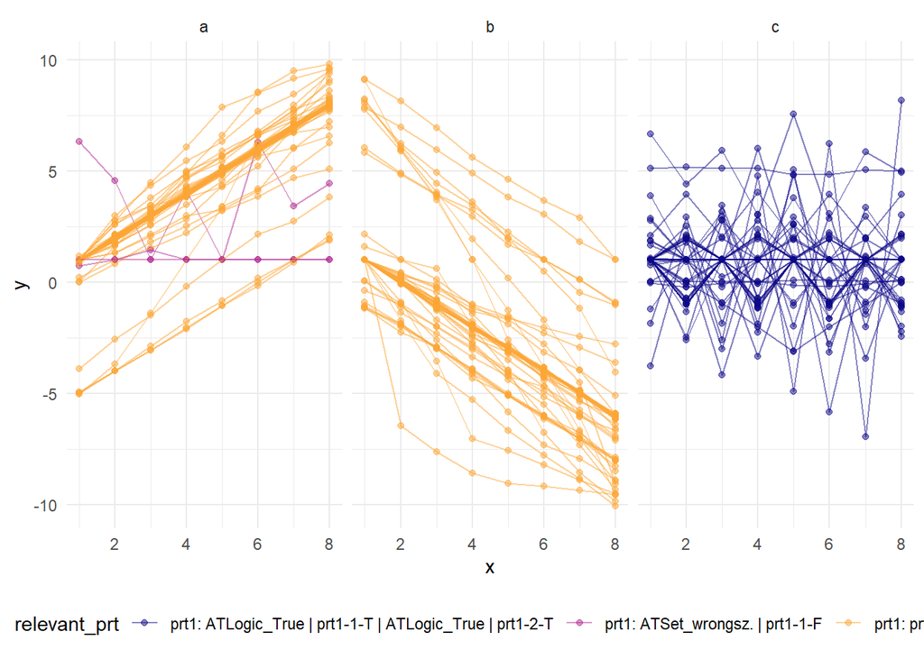

```r
responses_G4 <- responses_G %>%
  filter(str_detect(G_part, "G4")) %>%
  mutate(part = str_remove(G_part, "G4")) %>%
  select(part, group, username, relevant_prt, response) %>%
  mutate(response = str_remove_all(response, "\\[|\\]")) %>%
  separate(response, into = paste0("x_", c(1:8)), sep = ",")

responses_G4_long <- responses_G4 %>%
  pivot_longer(
    cols = starts_with("x_"),
    names_to = "x",
    values_to = "y",
    names_prefix = "x_"
  ) %>%
  mutate(across(c(x, y), as.numeric))

responses_G4_long %>%
  #filter(username %in% c("anon100")) %>%
  # filter(str_detect(relevant_prt, "prt1-1-F")) %>%
  ggplot(aes(x = x, y = y, group = username, colour = relevant_prt)) +
  geom_point(alpha = 0.5) +
  geom_line(alpha = 0.5) +
  facet_grid(cols = vars(part)) +
  scale_colour_viridis_d(end = 0.8, option = "plasma") +
  theme(legend.position = "bottom")
```

For G4a and G4b, it is striking that most students seem to have given examples that are arithmetic sequences (increasing for G4a and decreasing for G4b).

Since the plotted points are not constrained to be integers, students were not able to give exactly arithmetic answers due to the difficulty of placing the points exactly. However, computing the difference between successive terms and then looking at the standard deviation of those differences for each student, shows that many students gave examples that were extremely close to being arithmetic (i.e. the s.d. was very close to 0, meaning the term differences were very similar):

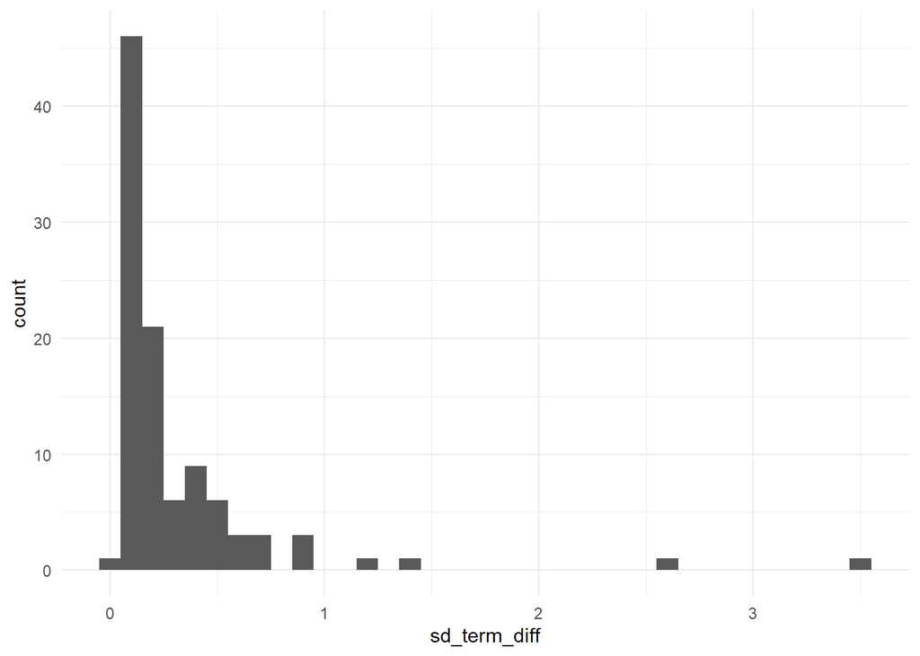

```r
responses_G4_long %>%
  filter(part %in% c("a", "b")) %>%
  group_by(part, group, username) %>%
  mutate(term_diff = y - lag(y)) %>%
  summarise(sd_term_diff = sd(term_diff, na.rm = TRUE), .groups = "drop") %>%
  ggplot(aes(x = sd_term_diff)) +
  geom_histogram(binwidth = 0.1)
```

For instance, here is an example of one student’s responses (note that the lines connecting the points were not visible to students):

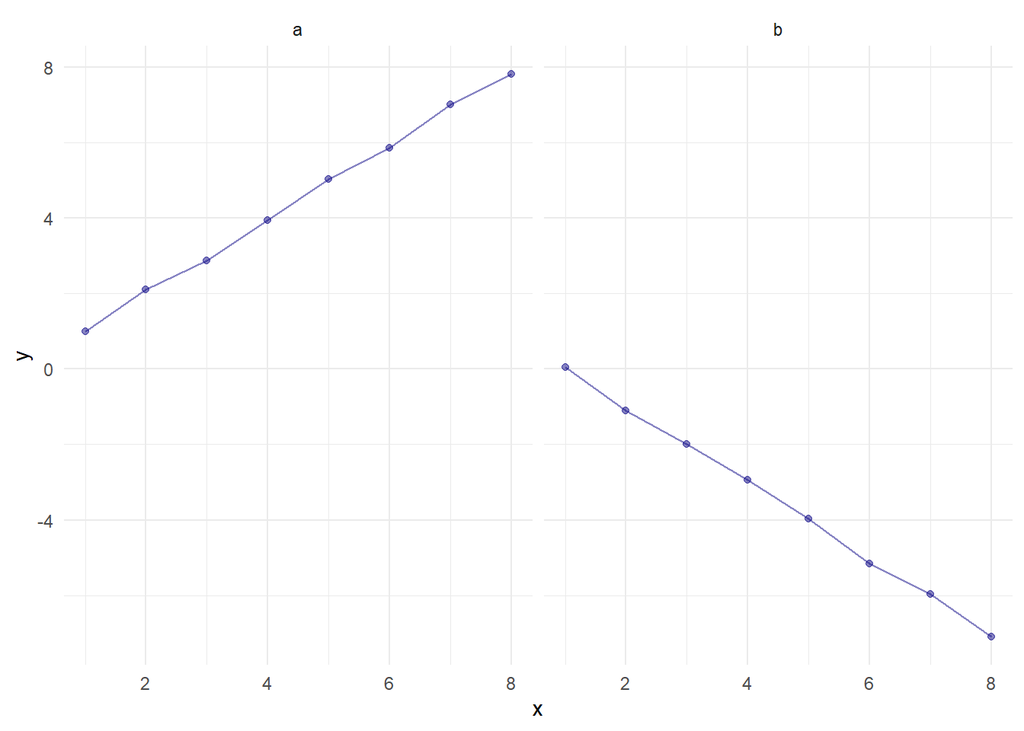

```r
responses_G4_long %>%
  filter(username %in% c("anon178"), part %in% c("a", "b")) %>%
  ggplot(aes(x = x, y = y, group = username, colour = relevant_prt)) +
  geom_point(alpha = 0.5) +
  geom_line(alpha = 0.5) +
  facet_grid(cols = vars(part)) +
  scale_colour_viridis_d(end = 0.8, option = "plasma") +
  theme(legend.position = "none")
```

For G4c, a common class of answers appears to be alternating in sign.

- alternating in sign

```r
responses_G4_long %>%
  filter(part == "c") %>%
  mutate(sign_y = sign(y)) %>%
  group_by(part, group, username, relevant_prt) %>%
  summarise(y_sign_seq = paste0(sign_y, collapse = ","), .groups = "drop") %>%
  group_by(y_sign_seq) %>%
  tally() %>%
  arrange(-n) %>%
  basic_kable()
```

| y_sign_seq | n |
| --- | --- |
| 1,1,1,1,1,1,1,1 | 25 |
| 1,-1,1,-1,1,-1,1,-1 | 10 |
| -1,1,-1,1,-1,1,-1,1 | 3 |
| 1,1,-1,1,-1,1,-1,1 | 2 |
| 1,1,1,-1,1,-1,1,1 | 2 |
| -1,-1,-1,1,-1,-1,-1,1 | 1 |
| 1,-1,1,-1,1,-1,1,1 | 1 |
| 1,-1,1,-1,1,0,1,-1 | 1 |
| 1,-1,1,1,1,-1,1,1 | 1 |
| 1,0,-1,-1,-1,-1,-1,0 | 1 |
| 1,1,-1,1,1,1,-1,1 | 1 |
| 1,1,-1,1,1,1,1,1 | 1 |
| 1,1,1,-1,1,-1,-1,-1 | 1 |
| 1,1,1,1,1,1,-1,1 | 1 |

- constant sequences also appear somewhat frequently:

```r
responses_G4_long %>%
  filter(part == "c") %>%
  group_by(part, group, username, relevant_prt) %>%
  summarise(constant = n_distinct(y)==1, .groups = "drop") %>%
  group_by(constant) %>%
  tally() %>%
  arrange(-n) %>%
  basic_kable()
```

| constant | n |
| --- | --- |
| FALSE | 45 |
| TRUE | 6 |

Focusing on the three students who gave an incorrect response to G4a:

- anon91 and anon139 did not respond to the subsequent parts
- anon229 gave correct responses to the subsequent parts - their example for G4c is quite similar to the one they gave for G4a, perhaps influenced by the feedback on G4a?

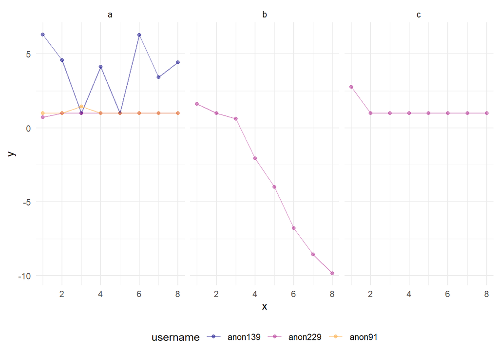

```r
responses_G4_long %>%
  filter(username %in% c("anon139", "anon229", "anon91")) %>%
  ggplot(aes(x = x, y = y, group = username, colour = username)) +
  geom_point(alpha = 0.5) +
  geom_line(alpha = 0.5) +
  facet_grid(cols = vars(part)) +
  scale_colour_viridis_d(end = 0.8, option = "plasma") +
  theme(legend.position = "bottom")
```